# notes

# Summary

```
## 'data.frame':    1105 obs. of  31 variables:
##  $ q0.1_time             : Date, format: "2017-04-18" "2017-04-18" ...
##  $ q1.1_usefb            : Factor w/ 4 levels "1","2","3","4": 4 1 4 4 4 3 1 4 4 4 ...
##  $ q1.2_useig            : Factor w/ 4 levels "1","2","3","4": 1 2 3 2 1 1 1 1 3 1 ...
##  $ q1.3_usesc            : Factor w/ 4 levels "1","2","3","4": 4 4 3 2 3 1 4 2 2 2 ...
##  $ q2.1_nocare           : Factor w/ 4 levels "1","2","3","4": 1 2 1 2 3 1 2 2 1 1 ...
##  $ q3.1_gender           : Factor w/ 2 levels "kvinde","mand": 1 2 1 2 2 1 2 1 1 2 ...
##  $ q4.1_age              : num  17 17 18 16 17 18 19 18 18 17 ...
##  $ q5.1_digedu           : Factor w/ 2 levels "ja","nej": 2 1 2 1 2 1 2 2 1 2 ...
##  $ q6.1_school           : Factor w/ 15 levels "borupgaard","egedal",..: 12 8 12 8 12 8 12 12 12 12 ...
##  $ q7.1_editedprivacy    : Factor w/ 4 levels "1","2","3","4": 4 2 3 3 2 4 3 3 4 4 ...
##  $ q8.1_freqpost         : Factor w/ 7 levels "1","2","3","4",..: 2 1 1 5 2 2 1 1 5 1 ...
##  $ q8.2_freqsend         : Factor w/ 7 levels "1","2","3","4",..: 7 1 6 6 4 4 4 7 6 6 ...
##  $ q8.3_freqread         : Factor w/ 7 levels "1","2","3","4",..: 6 6 6 6 2 4 6 7 6 6 ...
##  $ q9.1_seecontent       : Factor w/ 4 levels "1","2","3","4": 2 4 3 2 3 2 3 3 3 4 ...
```

[output cut: 18 more lines]

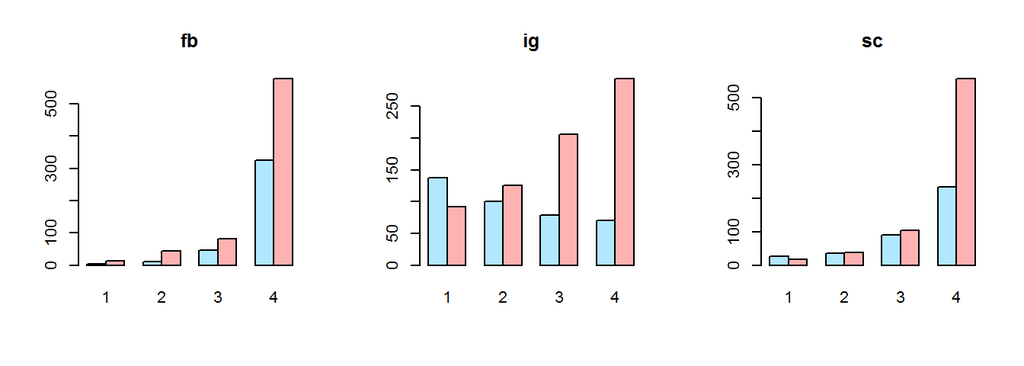

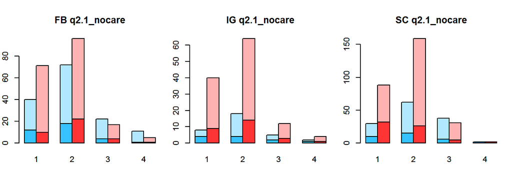

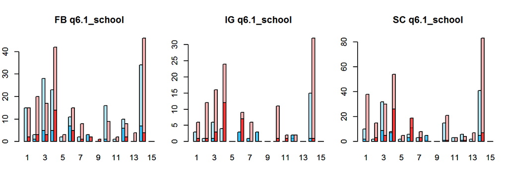

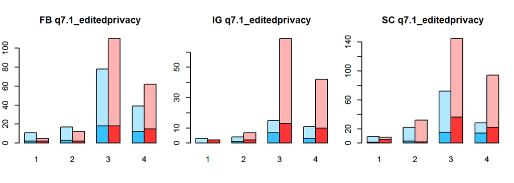

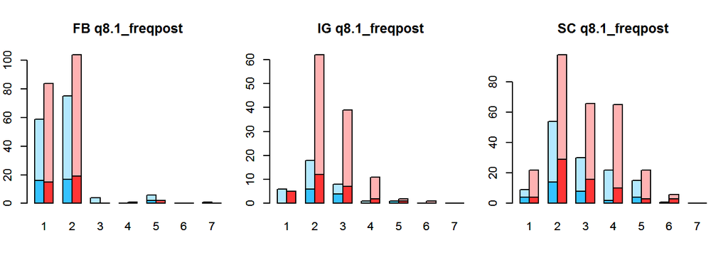

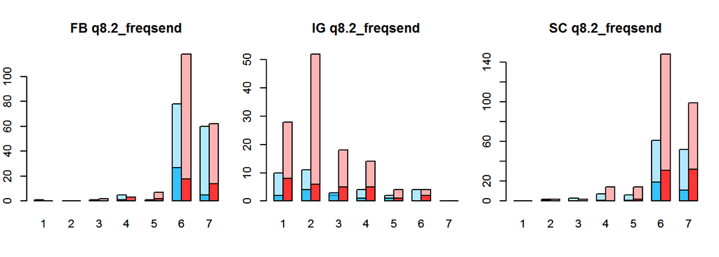

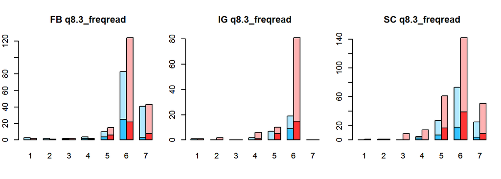

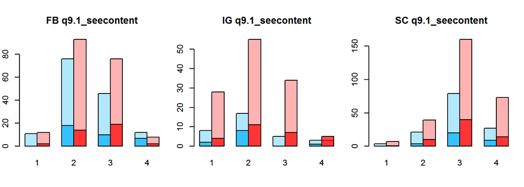

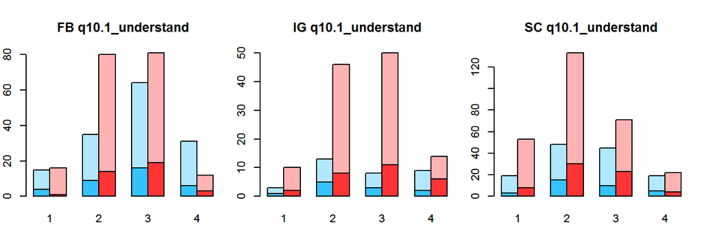

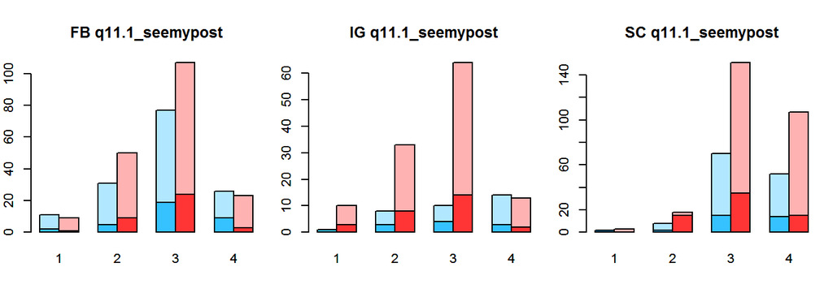

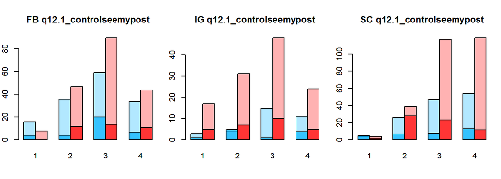

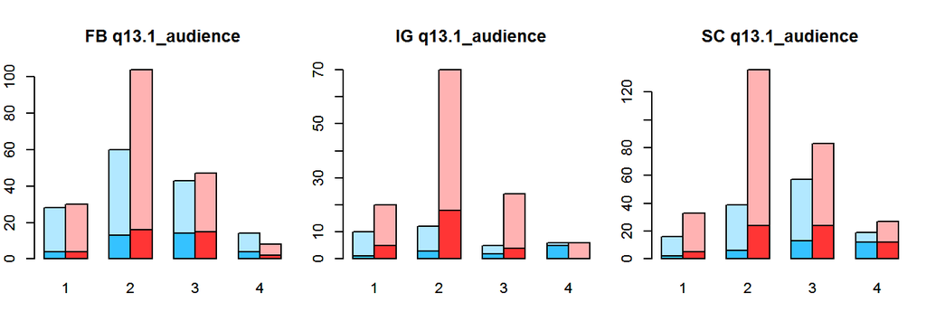

[6 more figures not shown]

# Luca’s take

## L1. Concern, Q2 ~ Q7

### Q2/Q7 ~ Q7/Q2 + DigEdu + platform

### Without interactions Q7 ~ …

Reduced: q7.1_editedprivacy ~ q2.1_nocare <environment: 0x0000000061bb58a8>

Coefficients:

Coefficients

| q2.1_nocare2 | -1.47 |
| --- | --- |
| q2.1_nocare4 | -2.18 |
| q2.1_nocare3 | -2.98 |

### With interactions Q7 ~ …

Reduced: q7.1_editedprivacy ~ q5.1_digedu + q2.1_nocare + q5.1_digedu:q2.1_nocare <environment: 0x0000000060d63098>

Coefficients:

Coefficients

| q5.1_digedunej:q2.1_nocare4 | 3.89 |
| --- | --- |
| q5.1_digedunej:q2.1_nocare3 | 0.04 |
| q5.1_digedunej:q2.1_nocare2 | -0.08 |
| q5.1_digedunej | -0.27 |
| q2.1_nocare2 | -1.42 |
| q2.1_nocare3 | -3.06 |
| q2.1_nocare4 | -4.94 |

### Without interactions Q2 ~ …

Reduced: q2.1_nocare ~ q7.1_editedprivacy <environment: 0x000000006164ef38>

Coefficients:

Coefficients

| q7.1_editedprivacy2 | 0.22 |
| --- | --- |
| q7.1_editedprivacy3 | -1.10 |
| q7.1_editedprivacy4 | -2.69 |

### With interactions Q2 ~ …

Reduced: q2.1_nocare ~ q7.1_editedprivacy <environment: 0x0000000060d9b128>

Coefficients:

Coefficients

| q7.1_editedprivacy2 | 0.22 |
| --- | --- |
| q7.1_editedprivacy3 | -1.10 |
| q7.1_editedprivacy4 | -2.69 |

### Q2 ~ Q7 + DigEdu + platform + demographic data

### Without interactions Q7 ~ …

Reduced: NULL

Coefficients:

Table: Coefficients

### With interactions Q7 ~ …

Reduced: q7.1_editedprivacy ~ q5.1_digedu + q2.1_nocare + q3.1_gender + q4.1_age + q5.1_digedu:q2.1_nocare + q5.1_digedu:q3.1_gender + q2.1_nocare:q4.1_age <environment: 0x0000000061ca0fb0>

Coefficients:

Coefficients

| q2.1_nocare4 | 5.63 |
| --- | --- |
| q5.1_digedunej:q2.1_nocare4 | 4.17 |
| q2.1_nocare2 | 2.03 |
| q4.1_age | 0.33 |
| q5.1_digedunej:q2.1_nocare3 | 0.27 |
| q3.1_gendermand | 0.21 |
| q5.1_digedunej:q2.1_nocare2 | 0.07 |
| q2.1_nocare3:q4.1_age | -0.08 |
| q2.1_nocare2:q4.1_age | -0.20 |
| q5.1_digedunej | -0.26 |
| q5.1_digedunej:q3.1_gendermand | -0.61 |
| q2.1_nocare4:q4.1_age | -0.61 |
| q2.1_nocare3 | -1.65 |

### Without interactions Q2 ~ …

Reduced: q2.1_nocare ~ q7.1_editedprivacy + q3.1_gender <environment: 0x0000000061bacfe8>

Coefficients:

Coefficients

| q3.1_gendermand | 0.43 |
| --- | --- |
| q7.1_editedprivacy2 | 0.27 |
| q7.1_editedprivacy3 | -1.00 |
| q7.1_editedprivacy4 | -2.59 |

### With interactions Q2 ~ …

Reduced: q2.1_nocare ~ q7.1_editedprivacy + q3.1_gender + q7.1_editedprivacy:q3.1_gender <environment: 0x0000000061c3d508>

Coefficients:

Coefficients

| q3.1_gendermand | 1.97 |
| --- | --- |
| q7.1_editedprivacy2 | 1.13 |
| q7.1_editedprivacy3 | -0.09 |
| q7.1_editedprivacy2:q3.1_gendermand | -1.38 |
| q7.1_editedprivacy3:q3.1_gendermand | -1.49 |
| q7.1_editedprivacy4 | -1.56 |
| q7.1_editedprivacy4:q3.1_gendermand | -1.90 |

## L2. Knowledge?!

Knowledge is defined as a factor whose levels are the combinations of the constituent questions (9-10, 11-12). For each pair of the questions 9,10 and 11-12 we create the derivative variables K1 and K2 such that for Q9 response i and Q10 response j the factor value of K1 is ij. K_1, K_2 have 16 elements each (4x4). In addition, based on the questions 9-19 we can build a wide range of derivative variables such as:

- knowledge (ignorance)
- awareness (naiveness)
- mindfulness (recklessness) etc

Below are tested the following 6 knowledge definitions:

### Q2, Q7 ~ K1/K2 + DigEdu + platform

### Without interactions, Q2, Q7 ~ K1 + digedu + platform

Reduced: q2.1_nocare ~ q5.1_digedu <environment: 0x0000000061c36888>

Coefficients:

Coefficients

| q5.1_digedunej | 0.21 |
| --- | --- |

Reduced: q7.1_editedprivacy ~ q5.1_digedu <environment: 0x0000000061c36888>

Coefficients:

Coefficients

| q5.1_digedunej | -0.24 |
| --- | --- |

### With interactions Q2, Q7 ~ K2 + digedu + platform

Reduced: q2.1_nocare ~ q5.1_digedu <environment: 0x0000000061b76488>

Coefficients: Reduced: q7.1_editedprivacy ~ q5.1_digedu <environment: 0x0000000061b76488>

Coefficients: $q2.1_nocare

Coefficients

| q5.1_digedunej | 0.21 |
| --- | --- |

$q7.1_editedprivacy

Coefficients

| q5.1_digedunej | -0.24 |
| --- | --- |

### Without interactions Q2, Q7 ~ K1 + digedu + platform + demo.dat

Reduced: q2.1_nocare ~ q5.1_digedu + q3.1_gender + q4.1_age + q6.1_school <environment: 0x0000000061c04fc0>

Coefficients: Reduced: q7.1_editedprivacy ~ q5.1_digedu + q3.1_gender + q4.1_age + q6.1_school <environment: 0x0000000061c04fc0>

Coefficients: $q2.1_nocare

Coefficients

| q6.1_schoolknord | 28.78 |
| --- | --- |
| q6.1_schoolespergrde | 0.93 |
| q6.1_schoolgefion | 0.82 |
| q6.1_schoolfrederiksborg | 0.70 |
| q6.1_schoolvirum | 0.68 |
| q3.1_gendermand | 0.59 |
| q6.1_schoolnrum | 0.49 |
| q6.1_schoolegedal | 0.43 |
| q6.1_schoolsydkysten | 0.37 |
| q6.1_schoolgladsaxe | 0.31 |
| q5.1_digedunej | 0.30 |
| q6.1_schooljohannesskolen | 0.25 |
| q6.1_schoolsukkertoppen | 0.21 |
| q6.1_schoolkbenhavnsmediegymnasium | 0.20 |
| q6.1_schoolrestad | -0.03 |
| q4.1_age | -0.15 |

$q7.1_editedprivacy

Coefficients

| q6.1_schoolkbenhavnsmediegymnasium | 0.32 |
| --- | --- |
| q4.1_age | 0.21 |
| q6.1_schoolsukkertoppen | -0.23 |
| q5.1_digedunej | -0.27 |
| q6.1_schooljohannesskolen | -0.29 |
| q6.1_schoolrestad | -0.33 |
| q6.1_schoolgladsaxe | -0.34 |
| q6.1_schoolsydkysten | -0.34 |
| q6.1_schoolegedal | -0.34 |
| q3.1_gendermand | -0.45 |
| q6.1_schoolnrum | -0.45 |
| q6.1_schoolfrederiksborg | -0.62 |
| q6.1_schoolvirum | -0.86 |
| q6.1_schoolespergrde | -1.04 |
| q6.1_schoolgefion | -1.85 |
| q6.1_schoolknord | -28.78 |

### With interactions Q2, Q7 ~ K3 + digedu + platform

Reduced: q2.1_nocare ~ q5.1_digedu <environment: 0x0000000061d2c238>

Coefficients: Reduced: q7.1_editedprivacy ~ q5.1_digedu <environment: 0x0000000061d2c238>

Coefficients: $q2.1_nocare

Coefficients

| q5.1_digedunej | 0.21 |
| --- | --- |

$q7.1_editedprivacy

Coefficients

| q5.1_digedunej | -0.24 |
| --- | --- |

### W/o interactions Q2, Q7 ~ K4 + digedu + paltform

Reduced: q2.1_nocare ~ q5.1_digedu <environment: 0x0000000061b939a8>

Coefficients: Reduced: q7.1_editedprivacy ~ q5.1_digedu <environment: 0x0000000061b939a8>

Coefficients: $q2.1_nocare

Coefficients

| q5.1_digedunej | 0.21 |
| --- | --- |

$q7.1_editedprivacy

Coefficients

| q5.1_digedunej | -0.24 |
| --- | --- |

### W interactions Q2, Q7 ~ K3 + digedu + platform + demo.dat

Reduced: q2.1_nocare ~ q5.1_digedu + q3.1_gender + q4.1_age + q6.1_school <environment: 0x0000000061af7f80>

Coefficients: Reduced: q7.1_editedprivacy ~ k3_ + q5.1_digedu + platform + q3.1_gender + q4.1_age + q6.1_school + q5.1_digedu:q3.1_gender + q3.1_gender:q4.1_age + q3.1_gender:q6.1_school <environment: 0x0000000061af7f80>

Coefficients: $q2.1_nocare

Coefficients

| q6.1_schoolknord | 28.78 |
| --- | --- |
| q6.1_schoolespergrde | 0.93 |
| q6.1_schoolgefion | 0.82 |
| q6.1_schoolfrederiksborg | 0.70 |
| q6.1_schoolvirum | 0.68 |
| q3.1_gendermand | 0.59 |
| q6.1_schoolnrum | 0.49 |
| q6.1_schoolegedal | 0.43 |
| q6.1_schoolsydkysten | 0.37 |
| q6.1_schoolgladsaxe | 0.31 |
| q5.1_digedunej | 0.30 |
| q6.1_schooljohannesskolen | 0.25 |
| q6.1_schoolsukkertoppen | 0.21 |
| q6.1_schoolkbenhavnsmediegymnasium | 0.20 |
| q6.1_schoolrestad | -0.03 |
| q4.1_age | -0.15 |

$q7.1_editedprivacy

Coefficients

| q6.1_schoolkbenhavnsmediegymnasium | 22.16 |
| --- | --- |
| k3_14 | 2.30 |
| k3_34 | 2.08 |
| k3_24 | 1.90 |
| k3_44 | 1.88 |
| k3_42 | 1.84 |
| k3_43 | 1.78 |
| k3_12 | 1.68 |
| k3_41 | 1.66 |
| k3_31 | 1.63 |
| k3_13 | 1.54 |
| k3_33 | 1.48 |
| q3.1_gendermand:q6.1_schoolnrum | 1.42 |
| k3_23 | 1.22 |
| k3_32 | 1.14 |
| q3.1_gendermand:q6.1_schooljohannesskolen | 1.08 |
| k3_22 | 0.90 |
| k3_21 | 0.84 |
| q3.1_gendermand:q6.1_schoolsukkertoppen | 0.58 |
| q6.1_schoolrestad | 0.43 |
| q3.1_gendermand:q4.1_age | 0.25 |
| q4.1_age | 0.14 |
| platformig | 0.08 |
| q3.1_gendermand:q6.1_schoolvirum | 0.06 |
| q5.1_digedunej | -0.01 |
| q6.1_schoolgladsaxe | -0.06 |
| q6.1_schoolsydkysten | -0.12 |
| q3.1_gendermand:q6.1_schoolfrederiksborg | -0.27 |
| q3.1_gendermand:q6.1_schoolespergrde | -0.27 |
| q6.1_schoolegedal | -0.29 |
| platformsc | -0.32 |
| q3.1_gendermand:q6.1_schoolegedal | -0.43 |
| q6.1_schoolfrederiksborg | -0.58 |
| q6.1_schoolsukkertoppen | -0.62 |
| q6.1_schooljohannesskolen | -0.65 |
| q5.1_digedunej:q3.1_gendermand | -0.67 |
| q3.1_gendermand:q6.1_schoolgladsaxe | -0.69 |
| q3.1_gendermand:q6.1_schoolgefion | -0.86 |
| q6.1_schoolvirum | -0.96 |
| q6.1_schoolespergrde | -0.96 |
| q3.1_gendermand:q6.1_schoolsydkysten | -1.01 |
| q6.1_schoolnrum | -1.08 |
| q6.1_schoolgefion | -1.41 |
| q3.1_gendermand:q6.1_schoolrestad | -3.38 |
| q3.1_gendermand | -4.31 |
| q3.1_gendermand:q6.1_schoolkbenhavnsmediegymnasium | -22.29 |
| q6.1_schoolknord | -27.65 |

### W/o interactions Q2, Q7 ~ K4 + digedu + platform + demo.dat

Reduced: q2.1_nocare ~ q5.1_digedu + q3.1_gender + q4.1_age + q6.1_school <environment: 0x0000000061a7aad8>

Coefficients: Reduced: q7.1_editedprivacy ~ q5.1_digedu + q3.1_gender + q4.1_age + q6.1_school <environment: 0x0000000061a7aad8>

Coefficients: $q2.1_nocare

Coefficients

| q6.1_schoolknord | 28.78 |
| --- | --- |
| q6.1_schoolespergrde | 0.93 |
| q6.1_schoolgefion | 0.82 |
| q6.1_schoolfrederiksborg | 0.70 |
| q6.1_schoolvirum | 0.68 |
| q3.1_gendermand | 0.59 |
| q6.1_schoolnrum | 0.49 |
| q6.1_schoolegedal | 0.43 |
| q6.1_schoolsydkysten | 0.37 |
| q6.1_schoolgladsaxe | 0.31 |
| q5.1_digedunej | 0.30 |
| q6.1_schooljohannesskolen | 0.25 |
| q6.1_schoolsukkertoppen | 0.21 |
| q6.1_schoolkbenhavnsmediegymnasium | 0.20 |
| q6.1_schoolrestad | -0.03 |
| q4.1_age | -0.15 |

$q7.1_editedprivacy

Coefficients

| q6.1_schoolkbenhavnsmediegymnasium | 0.32 |
| --- | --- |
| q4.1_age | 0.21 |
| q6.1_schoolsukkertoppen | -0.23 |
| q5.1_digedunej | -0.27 |
| q6.1_schooljohannesskolen | -0.29 |
| q6.1_schoolrestad | -0.33 |
| q6.1_schoolgladsaxe | -0.34 |
| q6.1_schoolsydkysten | -0.34 |
| q6.1_schoolegedal | -0.34 |
| q3.1_gendermand | -0.45 |
| q6.1_schoolnrum | -0.45 |
| q6.1_schoolfrederiksborg | -0.62 |
| q6.1_schoolvirum | -0.86 |
| q6.1_schoolespergrde | -1.04 |
| q6.1_schoolgefion | -1.85 |
| q6.1_schoolknord | -28.78 |

### W interactions Q2, Q7 ~ K5 + digedu + platform

Reduced: q2.1_nocare ~ q5.1_digedu <environment: 0x0000000061a6d360>

Coefficients: Reduced: q7.1_editedprivacy ~ k5_ + q5.1_digedu + platform <environment: 0x0000000061a6d360>

Coefficients: $q2.1_nocare

Coefficients

| q5.1_digedunej | 0.21 |
| --- | --- |

$q7.1_editedprivacy

Coefficients

| k5_34 | 0.44 |
| --- | --- |
| k5_44 | 0.41 |
| k5_12 | 0.35 |
| k5_14 | 0.16 |
| platformig | 0.14 |
| k5_42 | 0.13 |
| k5_23 | 0.02 |
| k5_24 | -0.19 |
| platformsc | -0.20 |
| k5_33 | -0.26 |
| k5_21 | -0.27 |
| k5_13 | -0.27 |
| q5.1_digedunej | -0.30 |
| k5_32 | -0.32 |
| k5_22 | -0.56 |
| k5_31 | -0.75 |
| k5_43 | -0.78 |
| k5_41 | -3.77 |

### W/o interactions Q2, Q7 ~ K6 + digedu + platform

Reduced: q2.1_nocare ~ q5.1_digedu <environment: 0x00000000616ec820>

Coefficients: Reduced: q7.1_editedprivacy ~ q5.1_digedu <environment: 0x00000000616ec820>

Coefficients: $q2.1_nocare

Coefficients

| q5.1_digedunej | 0.21 |
| --- | --- |

$q7.1_editedprivacy

Coefficients

| q5.1_digedunej | -0.24 |
| --- | --- |

### W interactions Q2, Q7 ~ K5 + digedu + platform + demo.dat

Reduced: q2.1_nocare ~ q5.1_digedu + q3.1_gender + q4.1_age + q6.1_school <environment: 0x0000000061c58430>

Coefficients: Reduced: q7.1_editedprivacy ~ k5_ + q5.1_digedu + q3.1_gender + q4.1_age + q6.1_school + q5.1_digedu:q3.1_gender + q3.1_gender:q4.1_age + q3.1_gender:q6.1_school <environment: 0x0000000061c58430>

Coefficients: $q2.1_nocare

Coefficients

| q6.1_schoolknord | 28.78 |
| --- | --- |
| q6.1_schoolespergrde | 0.93 |
| q6.1_schoolgefion | 0.82 |
| q6.1_schoolfrederiksborg | 0.70 |
| q6.1_schoolvirum | 0.68 |
| q3.1_gendermand | 0.59 |
| q6.1_schoolnrum | 0.49 |
| q6.1_schoolegedal | 0.43 |
| q6.1_schoolsydkysten | 0.37 |
| q6.1_schoolgladsaxe | 0.31 |
| q5.1_digedunej | 0.30 |
| q6.1_schooljohannesskolen | 0.25 |
| q6.1_schoolsukkertoppen | 0.21 |
| q6.1_schoolkbenhavnsmediegymnasium | 0.20 |
| q6.1_schoolrestad | -0.03 |
| q4.1_age | -0.15 |

$q7.1_editedprivacy

Coefficients

| q6.1_schoolkbenhavnsmediegymnasium | 22.11 |
| --- | --- |
| q3.1_gendermand:q6.1_schoolnrum | 1.44 |
| q3.1_gendermand:q6.1_schooljohannesskolen | 1.42 |
| q3.1_gendermand:q6.1_schoolsukkertoppen | 0.55 |
| q6.1_schoolrestad | 0.55 |
| k5_44 | 0.53 |
| k5_34 | 0.52 |
| k5_42 | 0.33 |
| q3.1_gendermand:q4.1_age | 0.25 |
| k5_12 | 0.16 |
| q4.1_age | 0.14 |
| q5.1_digedunej | -0.01 |
| q6.1_schoolsydkysten | -0.04 |
| k5_14 | -0.04 |
| q3.1_gendermand:q6.1_schoolvirum | -0.05 |
| q6.1_schoolgladsaxe | -0.09 |
| k5_21 | -0.10 |
| k5_24 | -0.11 |
| k5_23 | -0.11 |
| k5_33 | -0.20 |
| q6.1_schoolegedal | -0.27 |
| q3.1_gendermand:q6.1_schoolegedal | -0.32 |
| q3.1_gendermand:q6.1_schoolfrederiksborg | -0.34 |
| q3.1_gendermand:q6.1_schoolespergrde | -0.36 |
| k5_32 | -0.36 |
| q6.1_schoolfrederiksborg | -0.53 |
| q6.1_schoolsukkertoppen | -0.54 |
| k5_43 | -0.54 |
| k5_13 | -0.59 |
| q3.1_gendermand:q6.1_schoolgladsaxe | -0.59 |
| q6.1_schooljohannesskolen | -0.65 |
| q5.1_digedunej:q3.1_gendermand | -0.66 |
| k5_31 | -0.70 |
| k5_22 | -0.72 |
| q3.1_gendermand:q6.1_schoolgefion | -0.74 |
| q6.1_schoolvirum | -0.90 |
| q6.1_schoolespergrde | -0.93 |
| q6.1_schoolnrum | -1.14 |
| q6.1_schoolgefion | -1.37 |
| q3.1_gendermand:q6.1_schoolsydkysten | -1.69 |
| q3.1_gendermand:q6.1_schoolrestad | -3.72 |
| k5_41 | -4.07 |
| q3.1_gendermand | -4.27 |
| q3.1_gendermand:q6.1_schoolkbenhavnsmediegymnasium | -21.94 |
| q6.1_schoolknord | -27.79 |

### W/o interactions Q2, Q7 ~ K6 + digedu + platform + demo.dat

Reduced: q2.1_nocare ~ q5.1_digedu + q3.1_gender + q4.1_age + q6.1_school <environment: 0x000000006169a7a8>

Coefficients: Reduced: q7.1_editedprivacy ~ q5.1_digedu + q3.1_gender + q4.1_age + q6.1_school <environment: 0x000000006169a7a8>

Coefficients: $q2.1_nocare

Coefficients

| q6.1_schoolknord | 28.78 |
| --- | --- |
| q6.1_schoolespergrde | 0.93 |
| q6.1_schoolgefion | 0.82 |
| q6.1_schoolfrederiksborg | 0.70 |
| q6.1_schoolvirum | 0.68 |
| q3.1_gendermand | 0.59 |
| q6.1_schoolnrum | 0.49 |
| q6.1_schoolegedal | 0.43 |
| q6.1_schoolsydkysten | 0.37 |
| q6.1_schoolgladsaxe | 0.31 |
| q5.1_digedunej | 0.30 |
| q6.1_schooljohannesskolen | 0.25 |
| q6.1_schoolsukkertoppen | 0.21 |
| q6.1_schoolkbenhavnsmediegymnasium | 0.20 |
| q6.1_schoolrestad | -0.03 |
| q4.1_age | -0.15 |

$q7.1_editedprivacy

Coefficients

| q6.1_schoolkbenhavnsmediegymnasium | 0.32 |
| --- | --- |
| q4.1_age | 0.21 |
| q6.1_schoolsukkertoppen | -0.23 |
| q5.1_digedunej | -0.27 |
| q6.1_schooljohannesskolen | -0.29 |
| q6.1_schoolrestad | -0.33 |
| q6.1_schoolgladsaxe | -0.34 |
| q6.1_schoolsydkysten | -0.34 |
| q6.1_schoolegedal | -0.34 |
| q3.1_gendermand | -0.45 |
| q6.1_schoolnrum | -0.45 |
| q6.1_schoolfrederiksborg | -0.62 |
| q6.1_schoolvirum | -0.86 |
| q6.1_schoolespergrde | -1.04 |
| q6.1_schoolgefion | -1.85 |
| q6.1_schoolknord | -28.78 |